# course project

Roisin Kearins

5 December 2020

Introduction and Instructions

‘Using devices such as Jawbone Up, Nike FuelBand, and Fitbit it is now possible to collect a large amount of data about personal activity relatively inexpensively. These type of devices are part of the quantified self movement ??? a group of enthusiasts who take measurements about themselves regularly to improve their health, to find patterns in their behavior, or because they are tech geeks. One thing that people regularly do is quantify how much of a particular activity they do, but they rarely quantify how well they do it. In this project, your goal will be to use data from accelerometers on the belt, forearm, arm, and dumbell of 6 participants. They were asked to perform barbell lifts correctly and incorrectly in 5 different ways. More information is available from the website here: http://groupware.les.inf.puc-rio.br/har (see the section on the Weight Lifting Exercise Dataset).’

The training and test data set need to be initialised The data is downloaded / loaded into R from the following links: https://d396qusza40orc.cloudfront.net/predmachlearn/pml-training.csv https://d396qusza40orc.cloudfront.net/predmachlearn/pml-testing.csv

The data is loaded

```r
test_data <- read.csv('https://d396qusza40orc.cloudfront.net/predmachlearn/pml-testing.csv')

training_data <- read.csv('https://d396qusza40orc.cloudfront.net/predmachlearn/pml-training.csv')
```

The data is then cleaned First any columns with NA in are removed otherise the prediction will be inaccurate

```r
indColToRemove <- which(colSums(is.na(training_data) |training_data=="")>0.9*dim(training_data)[1])
TrainDataClean <- training_data[,-indColToRemove]
```

Any columns with un-needed data are then removed so that both the number of rows and columns are output.

```r
TrainDataClean <- TrainDataClean[,-c(1:7)]
dim(TrainDataClean)
```

```
## [1] 19622    53
```

```r
indColToRemove <- which(colSums(is.na(test_data) |test_data=="")>0.9*dim(test_data)[1])
TestDataClean <- test_data[,-indColToRemove]
TestDataClean <- TestDataClean[,-c(1:7)]

dim(TestDataClean)
```

```
## [1] 20 53
```

There are 53 columns in both datasets now and just the number of rows is different

Divide the training dataset into training and validation(partition the data)

```r
inTrainIndex = createDataPartition(TrainDataClean$classe, p = 0.75, list=FALSE)
training_training_data <- TrainDataClean[inTrainIndex,]
training_crossval_data <-TrainDataClean[-inTrainIndex,]

dim(training_training_data)
```

```
## [1] 14718    53
```

```r
dim(training_crossval_data)
```

```
## [1] 4904   53
```

The test dataset is then also altered in a similar way

```r
allNames <- names(TrainDataClean)
clean_test_data <- test_data[,allNames[1:52]]
```

Decision Tree

They are the building blocks of random forest models and allow for predictions on future data.

```r
set.seed(678)
decisionTreeMod <- train(classe ~., method='rpart', na.action = na.omit, data=training_training_data)
decisionTreePrediction <- predict(decisionTreeMod, training_crossval_data)
confusionMatrix(training_crossval_data$classe, decisionTreePrediction)
```

```
## Confusion Matrix and Statistics
##
##           Reference
## Prediction    A    B    C    D    E
##          A 1244   31   96    0   24
##          B  405  335  209    0    0
##          C  396   26  433    0    0
##          D  379  148  277    0    0
##          E  137  100  236    0  428
##
## Overall Statistics
##
##                Accuracy : 0.4976
##                  95% CI : (0.4835, 0.5116)
##     No Information Rate : 0.5222
##     P-Value [Acc > NIR] : 0.9997
##
##                   Kappa : 0.343
##
##  Mcnemar's Test P-Value : NA
##
## Statistics by Class:
##
##                      Class: A Class: B Class: C Class: D Class: E
## Sensitivity            0.4857  0.52344   0.3461       NA  0.94690
## Specificity            0.9356  0.85600   0.8845   0.8361  0.89376
## Pos Pred Value         0.8918  0.35300   0.5064       NA  0.47503
## Neg Pred Value         0.6247  0.92288   0.7980       NA  0.99400
## Prevalence             0.5222  0.13051   0.2551   0.0000  0.09217
## Detection Rate         0.2537  0.06831   0.0883   0.0000  0.08728
## Detection Prevalence   0.2845  0.19352   0.1743   0.1639  0.18373
## Balanced Accuracy      0.7107  0.68972   0.6153       NA  0.92033
```

Plot the tree

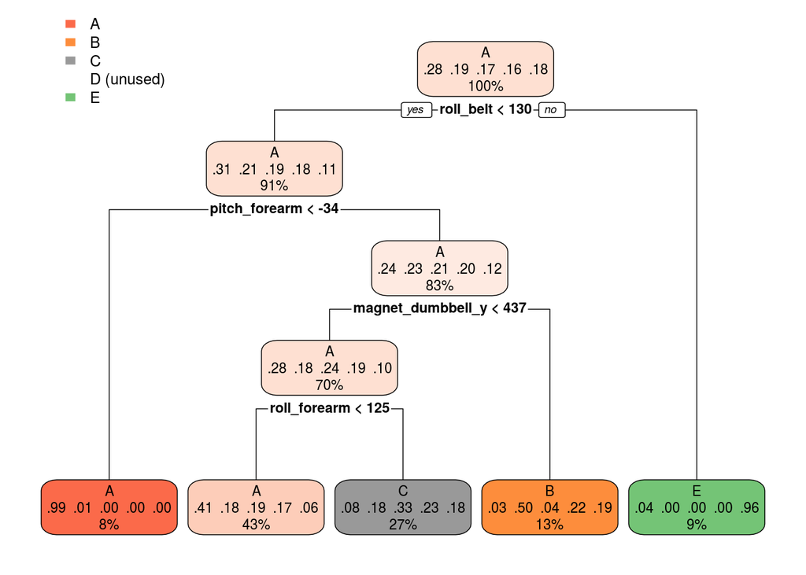

```r
rpart.plot(decisionTreeMod$finalModel)
```

Above shows a prediction of how the exercise groups are fulfilled Random Forest In the most simplistic format these models are that they are a just Decision Trees in an exponetial amount all based on different parameters of different data sets. It is commonly used for regression and classification tasks and is more commonly used because it is simple to use. It is random because of when the models are initially generated the data in the columns in randomly selected along with the data in the rows.

parallel processing to speed up the Random Forest model

```r
intervalStart <- Sys.time()
cluster <- makeCluster(detectCores() - 1) # convention to leave 1 core for OS
registerDoParallel(cluster)
```

configure the control

```r
controlRf <- trainControl(method = "cv",5)
```

Parallel Ramdom Forest

```r
start.time <- proc.time()
rfMod <- train(classe ~.,method='rf', data=training_training_data,trControl=controlRf, ntree=250)
stop.time <- proc.time()
run.time<-stop.time -start.time
print(run.time)
```

```
##    user  system elapsed
##  19.590   0.209 196.107
```

The Random forest model can be used to provide a prediction and allow for the accuracy to be visualised

```r
rfPrediction <- predict(rfMod, training_crossval_data)
confusionMatrix(training_crossval_data$classe, rfPrediction)
```

```
## Confusion Matrix and Statistics
##
##           Reference
## Prediction    A    B    C    D    E
##          A 1394    0    0    0    1
##          B    4  944    1    0    0
##          C    0    3  852    0    0
##          D    0    0   11  793    0
##          E    0    0    0    2  899
##
## Overall Statistics
##
##                Accuracy : 0.9955
##                  95% CI : (0.9932, 0.9972)
##     No Information Rate : 0.2851
##     P-Value [Acc > NIR] : < 2.2e-16
##
##                   Kappa : 0.9943
##
##  Mcnemar's Test P-Value : NA
##
## Statistics by Class:
##
##                      Class: A Class: B Class: C Class: D Class: E
## Sensitivity            0.9971   0.9968   0.9861   0.9975   0.9989
## Specificity            0.9997   0.9987   0.9993   0.9973   0.9995
## Pos Pred Value         0.9993   0.9947   0.9965   0.9863   0.9978
## Neg Pred Value         0.9989   0.9992   0.9970   0.9995   0.9998
## Prevalence             0.2851   0.1931   0.1762   0.1621   0.1835
## Detection Rate         0.2843   0.1925   0.1737   0.1617   0.1833
## Detection Prevalence   0.2845   0.1935   0.1743   0.1639   0.1837
## Balanced Accuracy      0.9984   0.9978   0.9927   0.9974   0.9992
```

Prediction

```r
predict(rfMod, clean_test_data)
```

```
##  [1] B A B A A E D B A A B C B A E E A B B B
## Levels: A B C D E
```

Other models- There were other models that could have been used but unfortunately when they were both run in R and in knitted they took closer to an hour to finish.

```r
#set.seed(100)
# model 1: gbm- gradient boosting method
#modFit1<-train(classe~.,method="gbm",data=TrainDataClean, verbose = FALSE, na.action = na.omit )
#print(modFit1)
#plot(modFit1)
#prediction <- predict(modFit1, newdata= clean_test_data)
#confusionmat <- confusionMatrix(clean_test_data$classe,prediction)
```